# Final Plots

```r
library(dplyr)
```

```r
library(tidyr)
library(ggplot2)
library(reshape2)
library(boot)
library(glmnet)
library(tidyverse)
library(scales)
library(ROCR)
library(directlabels)

theme_set(theme_bw())
```

## Student Drop Outs Throughout High School

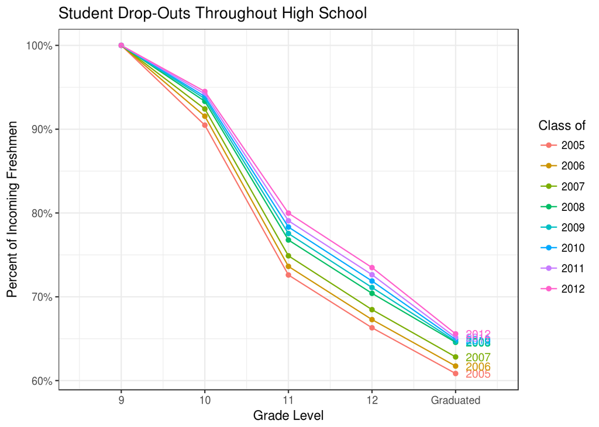

```r
load('/data/nycdoe/clean_data/hs_student_dropouts_data.Rdata')

final_df_2 %>%
  filter(year<=2012) %>%
  ggplot(aes(x=grade, y=num_students, color=as.factor(year))) +
  geom_point() +
  geom_line() +
  scale_y_continuous(labels = percent) +
  scale_x_continuous(breaks=seq(9,13,1), labels=c('9'='9', '10'='10', '11'='11', '12'='12', '13'='Graduated'), expand=c(0, 0.75)) +
  geom_dl(aes(label = as.factor(year)), method = list(dl.trans(x = x + .3), "last.points", cex = 0.8)) +
  labs(x="Grade Level", y="Percent of Incoming Freshmen", title="Student Drop-Outs Throughout High School", color="Class of")
```

## Student Drop Outs Throughout High School - Faceted by Ethnicity

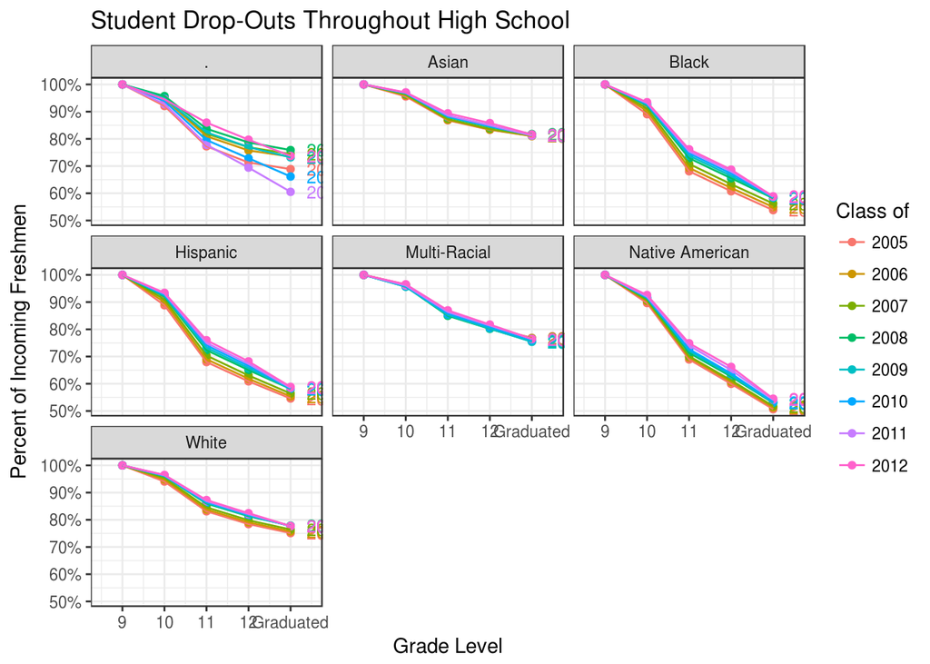

```r
load('/data/nycdoe/clean_data/hs_student_dropouts_eth_data.Rdata')

final_df_2 %>%
  filter(year<=2012) %>%
  ggplot(aes(x=grade, y=num_students, color=as.factor(year))) +
  geom_point() +
  geom_line() +
  scale_y_continuous(labels = percent) +
  scale_x_continuous(breaks=seq(9,13,1), labels=c('9'='9', '10'='10', '11'='11', '12'='12', '13'='Graduated'), expand=c(0, 0.75)) +
  geom_dl(aes(label = as.factor(year)), method = list(dl.trans(x = x + .3), "last.points", cex = 0.8)) +
  labs(x="Grade Level", y="Percent of Incoming Freshmen", title="Student Drop-Outs Throughout High School", color="Class of") +
  facet_wrap(~ethnicity)
```

## Student Drop Outs Throughout High School - Faceted by Gender

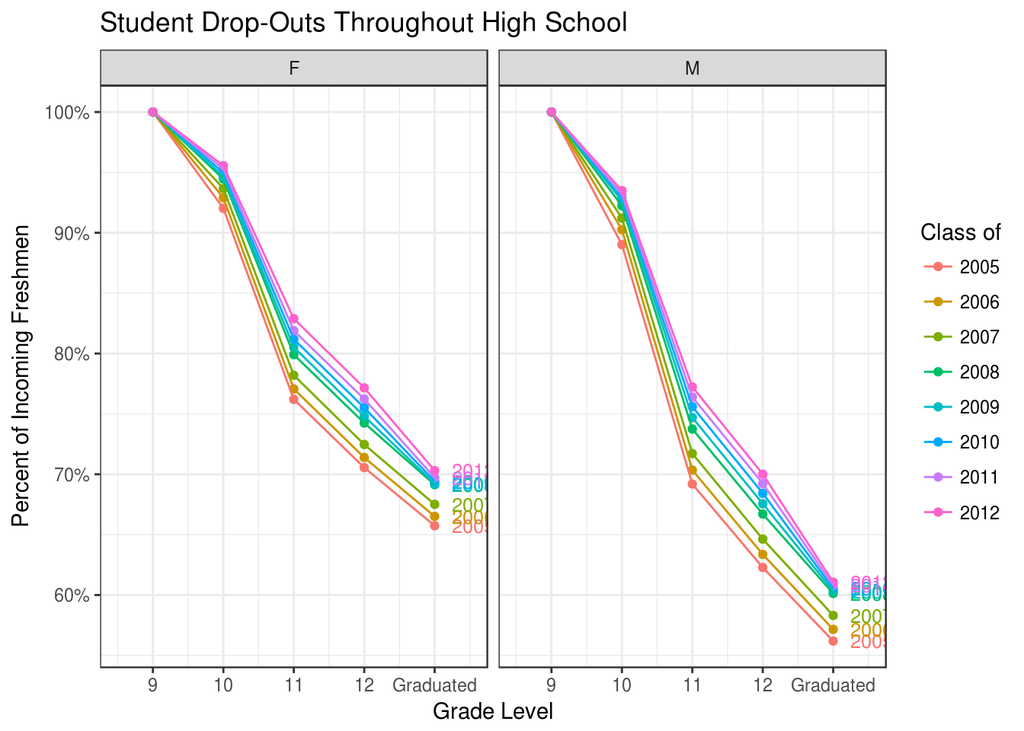

```r
load('/data/nycdoe/clean_data/hs_student_dropouts_gender_data.Rdata')

final_df_2 %>%
  filter(year<=2012) %>%
  ggplot(aes(x=grade, y=num_students, color=as.factor(year))) +
  geom_point() +
  geom_line() +
  scale_y_continuous(labels = percent) +
  scale_x_continuous(breaks=seq(9,13,1), labels=c('9'='9', '10'='10', '11'='11', '12'='12', '13'='Graduated'), expand=c(0, 0.75)) +
  geom_dl(aes(label = as.factor(year)), method = list(dl.trans(x = x + .3), "last.points", cex = 0.8)) +
  labs(x="Grade Level", y="Percent of Incoming Freshmen", title="Student Drop-Outs Throughout High School", color="Class of") +
  facet_wrap(~sex)
```

## Average Grade-Wise Continuation Rates Across 2005-2014

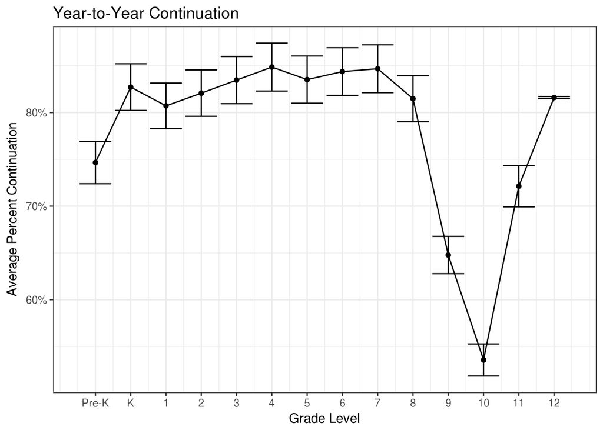

```r
load('/data/nycdoe/clean_data/average_gradewise_continuation_rates.Rdata')

continuation_rates %>%
  group_by(grade_level) %>%
  summarise(avg_continuation=mean(continuation_rate), se=sd(continuation_rate)/n()) %>%
  ggplot(aes(x=grade_level, y=avg_continuation)) +
  scale_x_continuous(breaks=seq(-1, 12, 1), labels=c('-1'='Pre-K', '0'='K', '1'='1', '2'='2', '3'='3', '4'='4', '5'='5', '6'='6', '7'='7', '8'='8', '9'='9', '10'='10', '11'='11', '12'='12'), expand=c(0, 0.75)) +
  scale_y_continuous(labels = percent) +
  geom_point() +
  geom_line() +
  labs(x="Grade Level", y="Average Percent Continuation", title="Year-to-Year Continuation") +
  geom_errorbar(aes(ymin = avg_continuation-se, ymax = avg_continuation+se))
```

## Average Grade-Wise Continuation Rates Split by Year

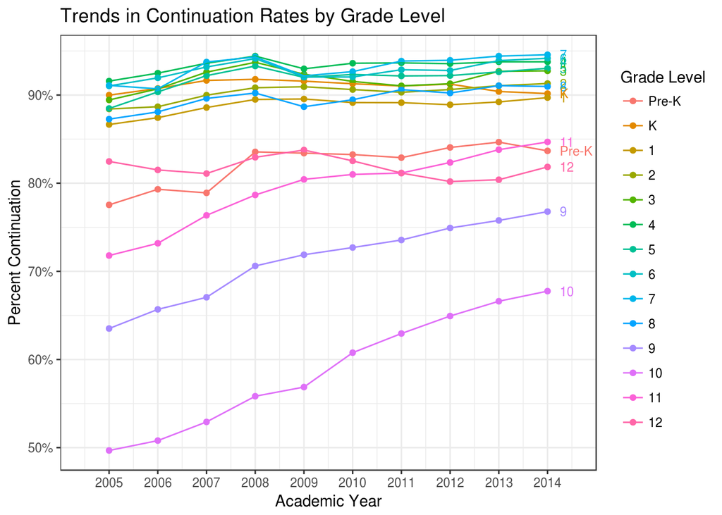

```r
continuation_rates %>%
  filter(year!=2015) %>%
  mutate(grade_level=as.character(grade_level)) %>%
  mutate(grade_level=ifelse(grade_level=='-1','Pre-K',
                            ifelse(grade_level=='0', 'K',
                                   grade_level))) %>%
  ggplot(aes(x=year, y=continuation_rate, color=factor(grade_level, levels=c('Pre-K', 'K', '1', '2', '3', '4', '5', '6', '7', '8', '9', '10', '11', '12')))) +
  geom_point() +
  geom_line() +
  labs(x="Academic Year", y="Percent Continuation", title="Trends in Continuation Rates by Grade Level", color="Grade Level") +
  scale_y_continuous(labels = percent) +
  scale_x_continuous(breaks=seq(2005, 2014, 1), expand=c(0, 1)) +
  geom_dl(aes(label = as.factor(grade_level)), method = list(dl.trans(x = x + .3), "last.points", cex = 0.75))
```

# Model: did_not_continue ~ grade_level + sex + ethnicity + ell + poverty + perc_attendance + quantiled_GPA + school_avg_attendance + school_avg_grad + school_avg_English + school_avg_History + school_avg_Language + school_avg_Math + school_avg_Science

## Coefficients

> coef(model_5) 107 x 1 sparse Matrix of class “dgCMatrix” s0 (Intercept) -0.110625063 (Intercept) .  
> grade_level1 0.418244557 grade_level-1 -0.074831362 grade_level10 2.656616302 grade_level11 1.874840792 grade_level12 1.160446307 grade_level2 0.319546452 grade_level3 0.139231775 grade_level4 -0.047714778 grade_level5 0.220681755 grade_level6 0.308763573 grade_level7 0.189668389 grade_level8 0.618494254 grade_level9 2.100186840 sexM 0.183916486 ethnicityAsian -0.273433214 ethnicityBlack 0.060348604 ethnicityHispanic -0.104540124 ethnicityMulti-Racial 0.156259207 ethnicityNative American -0.016677044 ethnicityWhite -0.148575450 ell 0.362096565 poverty -0.177393737 perc_attendance10 -0.321894580 perc_attendance100 -3.957311098 perc_attendance20 -0.522810358 perc_attendance30 -0.792461426 perc_attendance40 -1.102650795 perc_attendance50 -1.436796287 perc_attendance60 -1.835128123 perc_attendance70 -2.303149960 perc_attendance80 -2.828415891 perc_attendance90 -3.406070502 quantiled_GPA10 0.084605308 quantiled_GPA2 -0.293418907 quantiled_GPA3 -0.333660314 quantiled_GPA4 -0.345121123 quantiled_GPA5 -0.301056779 quantiled_GPA6 -0.311366801 quantiled_GPA7 -0.211128917 quantiled_GPA8 -0.160189884 quantiled_GPA9 -0.035671002 quantiled_GPAMissing 0.205950212 school_avg_attendance10 -0.191433759 school_avg_attendance100 0.162172608 school_avg_attendance20 -0.883179829 school_avg_attendance30 0.300304752 school_avg_attendance40 0.122643347 school_avg_attendance50 0.463188626 school_avg_attendance60 0.259482354 school_avg_attendance70 -0.034656320 school_avg_attendance80 0.014018812 school_avg_attendance90 -0.001099207 school_avg_attendanceNot Applicable 0.272905853 school_avg_grad10 -0.720056084 school_avg_grad100 -3.205442931 school_avg_grad20 -0.817164379 school_avg_grad30 -0.663692559 school_avg_grad40 -1.080333303 school_avg_grad50 -1.285676932 school_avg_grad60 -1.665819093 school_avg_grad70 -1.807981993 school_avg_grad80 -2.002536153 school_avg_grad90 -2.504625701 school_avg_gradNot Applicable -0.617160124 school_avg_English20 0.440004006 school_avg_English30 0.321231745 school_avg_English40 0.066901780 school_avg_English50 0.438120672 school_avg_English60 0.556773788 school_avg_English70 0.636096990 school_avg_English80 0.451221722 school_avg_English90 0.197881136 school_avg_EnglishMissing 0.189212645 school_avg_EnglishNot Applicable 0.243227114 school_avg_History40 0.157669797 school_avg_History50 0.069993443 school_avg_History60 0.008650314 school_avg_History70 0.137211464 school_avg_History80 -0.013869884 school_avg_History90 -0.011203772 school_avg_HistoryMissing -0.070460997 school_avg_HistoryNot Applicable 0.003919970 school_avg_Language100 0.157527439 school_avg_Language30 0.035323122 school_avg_Language60 0.983180750 school_avg_Language70 -0.112429084 school_avg_Language80 0.035415857 school_avg_Language90 0.155547613 school_avg_LanguageMissing 0.195185103 school_avg_LanguageNot Applicable 0.141311968 school_avg_Math50 0.662214766 school_avg_Math60 0.706552063 school_avg_Math70 0.816062328 school_avg_Math80 0.875305681 school_avg_Math90 0.765416242 school_avg_MathMissing 0.830381998 school_avg_MathNot Applicable 0.782409904 school_avg_Science40 0.521784959 school_avg_Science50 0.586960045 school_avg_Science60 0.488471262 school_avg_Science70 0.383724621 school_avg_Science80 0.265078384 school_avg_Science90 0.211097957 school_avg_ScienceMissing 0.476142627 school_avg_ScienceNot Applicable 0.397416778

## Model Stats

Accuracy

```r
load('/data/nycdoe/clean_data/model_5_stats.Rdata')

accuracy <-
  model_5_stats %>%
  summarise(accuracy=sum(num_correct)/sum(total), baseline_accuracy=sum(cont)/sum(total))

accuracy
```

```
##    accuracy baseline_accuracy
## 1 0.8811248         0.8479293
```

Precision

```r
precision <-
  model_5_stats %>%
  filter(p_did_not_continue>=0.5) %>%
  summarise(prec=sum(did_not_cont)/sum(total))

precision
```

```
##       prec
## 1 0.760989
```

True Positive Rate

```r
tpr <-
  model_5_stats %>%
  summarise(tpr=sum(did_not_cont*(p_did_not_continue>=0.5))/sum(did_not_cont))

tpr
```

```
##         tpr
## 1 0.3182439
```

False Positive Rate

```r
fpr <-
  model_5_stats %>%
  summarise(fpr=sum(cont*(p_did_not_continue>=0.5))/sum(cont))

fpr
```

```
##          fpr
## 1 0.01792609
```

AUC and ROC

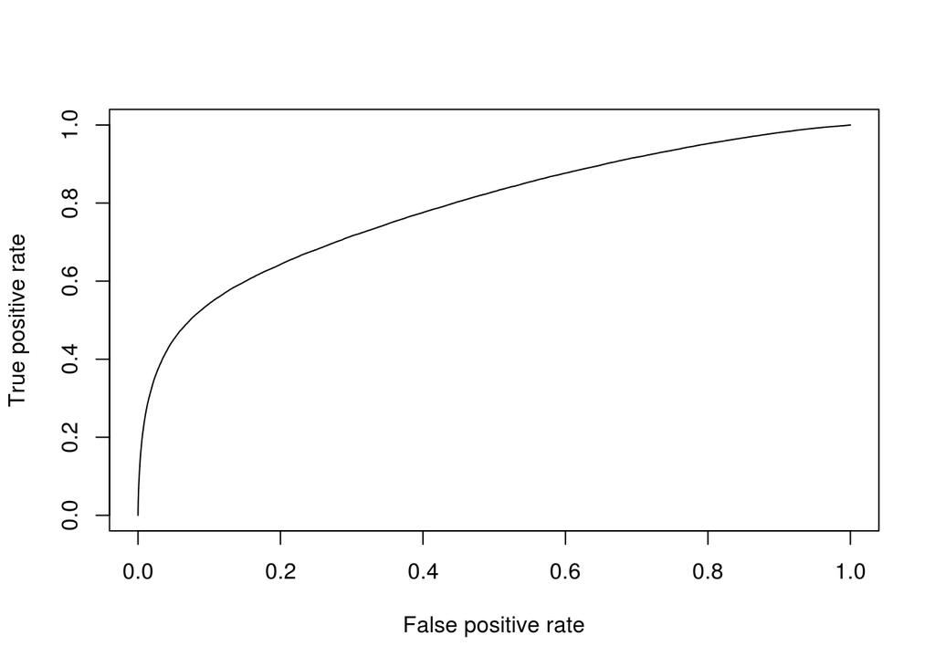

```r
auc_data <-
  model_5_stats %>%
  select(cont, did_not_cont, p_did_not_continue) %>%
  gather('label', 'count', 1:2) %>%
  mutate(label=ifelse(label=='cont', 0, 1)) %>%
  mutate(actual_did_not_continue=label) %>%
  select(actual_did_not_continue, p_did_not_continue, count)

auc_data <- auc_data[rep(row.names(auc_data), auc_data$count), 1:2]

pred <- prediction(auc_data$p_did_not_continue, auc_data$actual_did_not_continue)

perf_nb <- performance(pred, measure='tpr', x.measure='fpr')

plot(perf_nb)
```

```r
performance(pred, 'auc')
```

```
## An object of class "performance"
## Slot "x.name":
## [1] "None"
##
## Slot "y.name":
## [1] "Area under the ROC curve"
##
## Slot "alpha.name":
## [1] "none"
##
## Slot "x.values":
## list()
##
## Slot "y.values":
## [[1]]
## [1] 0.7888072
##
##
## Slot "alpha.values":
## list()
```

## Calibration Plot

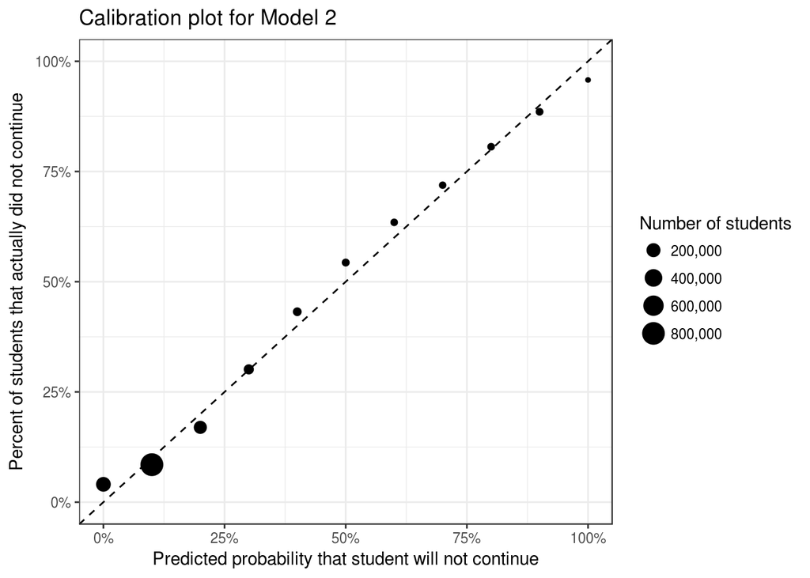

```r
model_5_stats %>%
  group_by(predicted=round(p_did_not_continue*10)/10) %>%
  summarise(num=sum(total), actual=sum(did_not_cont)/sum(total)) %>%
  ggplot(aes(x=predicted, y=actual, size=num)) +
  geom_point() +
  geom_abline(linetype=2) +
  scale_x_continuous(labels=percent, lim=c(0,1)) +
  scale_y_continuous(labels=percent, lim=c(0,1)) +
  scale_size_continuous(labels=comma) +
  labs(title='Calibration plot for Model 2', x='Predicted probability that student will not continue', y= 'Percent of students that actually did not continue', size='Number of students')
```

## What Percent of Dropouts Are We Catching?

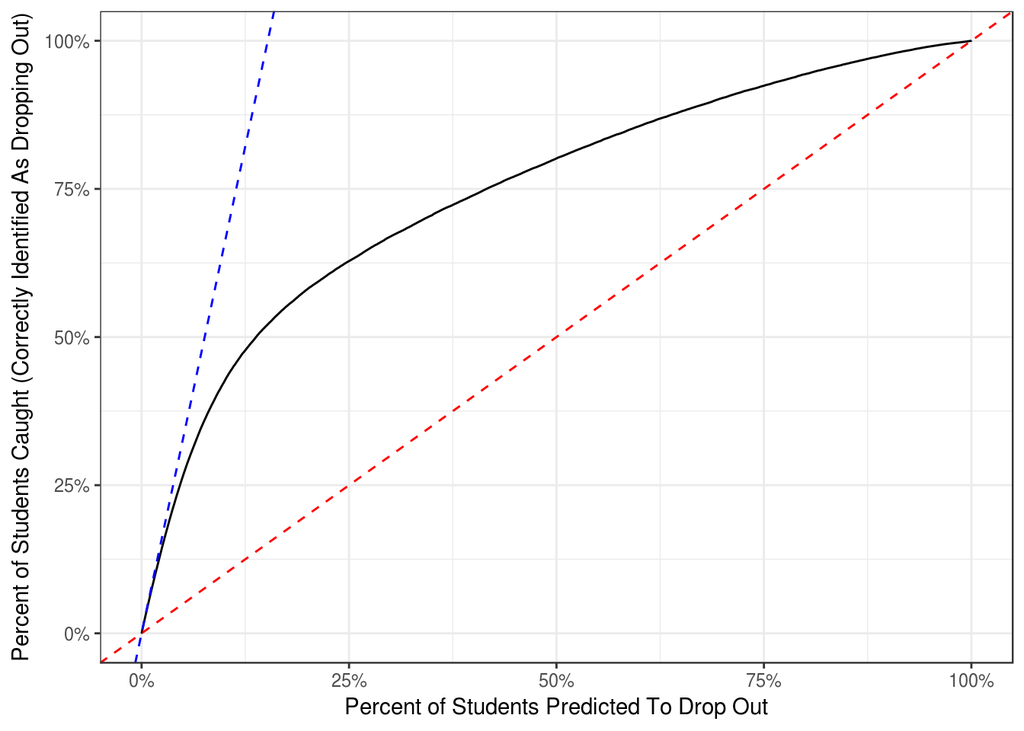

```r
b <- data.frame(c(1,1))
b[1,1] <-
  model_5_stats %>%
  summarise(sum(did_not_cont)/sum(total))

model_5_stats %>%
  arrange(desc(p_did_not_continue)) %>%
  mutate(cum_total=cumsum(total), perc_cum_total=cum_total/sum(total), cum_did_not_cont=cumsum(did_not_cont), perc_cum_did_not_cont=cum_did_not_cont/sum(did_not_cont)) %>%
  ggplot(aes(x=perc_cum_total, y=perc_cum_did_not_cont)) +
  geom_line() +
  scale_x_continuous(labels=percent) +
  scale_y_continuous(labels=percent) +
  labs(x="Percent of Students Predicted To Drop Out", y="Percent of Students Caught (Correctly Identified As Dropping Out)") +
  geom_abline(linetype='dashed', color='red') +
  geom_abline(linetype='dashed', slope=(1/b[1,1]), intercept=0, color='blue')
```

## How Many Students We Intervened With Weren’t Actually Going to Drop Out? ‘Top K Curve’

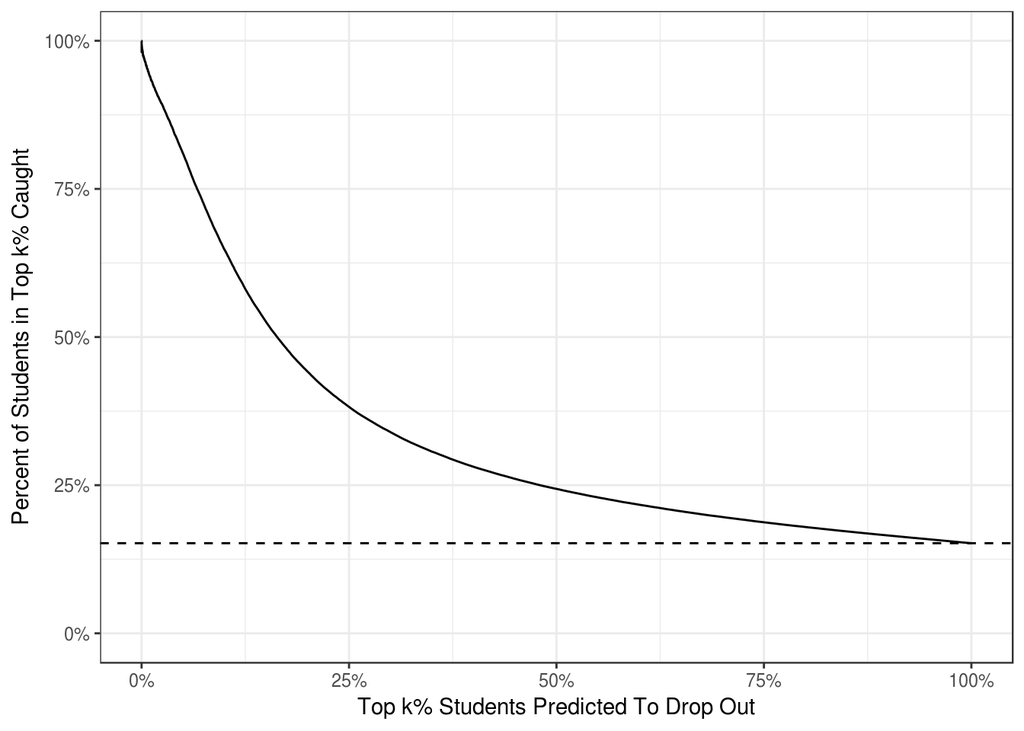

```r
baseline <-
  model_5_stats %>%
  summarise(base=sum(did_not_cont)/sum(total))

model_5_stats %>%
  arrange(desc(p_did_not_continue)) %>%
  mutate(cum_total=cumsum(total), perc_cum_total=cum_total/sum(total), cum_did_not_cont=cumsum(did_not_cont), p_dropout_in_top_k=cum_did_not_cont/cum_total) %>%
  ggplot(aes(x=perc_cum_total, y=p_dropout_in_top_k)) +
  geom_line() +
  scale_x_continuous(labels=percent) +
  scale_y_continuous(labels=percent, limits=c(0,1)) +
  labs(x="Top k% Students Predicted To Drop Out", y="Percent of Students in Top k% Caught") +
  geom_hline(yintercept = baseline[1,1], linetype='dashed')
```

## Our Model’s Predictions for a ‘Typical’ Student - Faceted by Ethnicity and Gender

Typical Student: ell=0, poverty=1, perc_attendance=100, quantiled_GPA=‘Missing’, school_avg_attendance=90, school_avg_grad=60, school_avg_English=60, school_avg_History=60, school_avg_Language=90, school_avg_Math=60, school_avg_Science=60

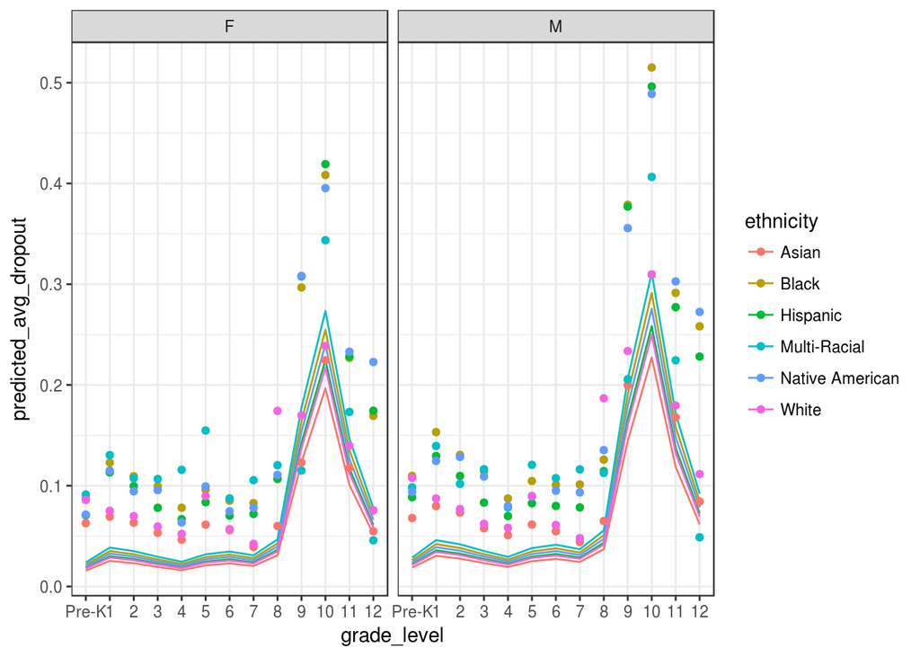

```r
load('/data/nycdoe/clean_data/model_5_stats_eth_gender.Rdata')

model_5_stats_on_artificial_test_with_features_4 %>%
  group_by(grade_level, ethnicity, sex) %>%
  summarise(predicted_avg_dropout=mean(p_did_not_continue), actual_avg_dropout=mean(actual_avg_dropout)) %>%
  ggplot(aes(x=grade_level, y=predicted_avg_dropout, color=ethnicity, group=ethnicity)) +
  geom_line() +
  geom_point(aes(x=grade_level, y=actual_avg_dropout)) +
  facet_wrap(~ sex)
```